# [COVID-19 Situation Report](https://unlikelyvolcano.com/covid-report.html)

[UnlikelyVolcano (David Azizi)](https://unlikelyvolcano.com)

This report was last updated on 2020-03-22. Data courtesy of [JHU CSSE](https://systems.jhu.edu/research/public-health/ncov/).

[Worldwide report here.](https://unlikelyvolcano.com/covid-world.html)

## United States

### Cumulative Cases

The cumulative number of cases doesn’t tell us much – it’s not possible for this number to go down. We can see that the growth seems to be accelerating, but we will look closer in the next tab.

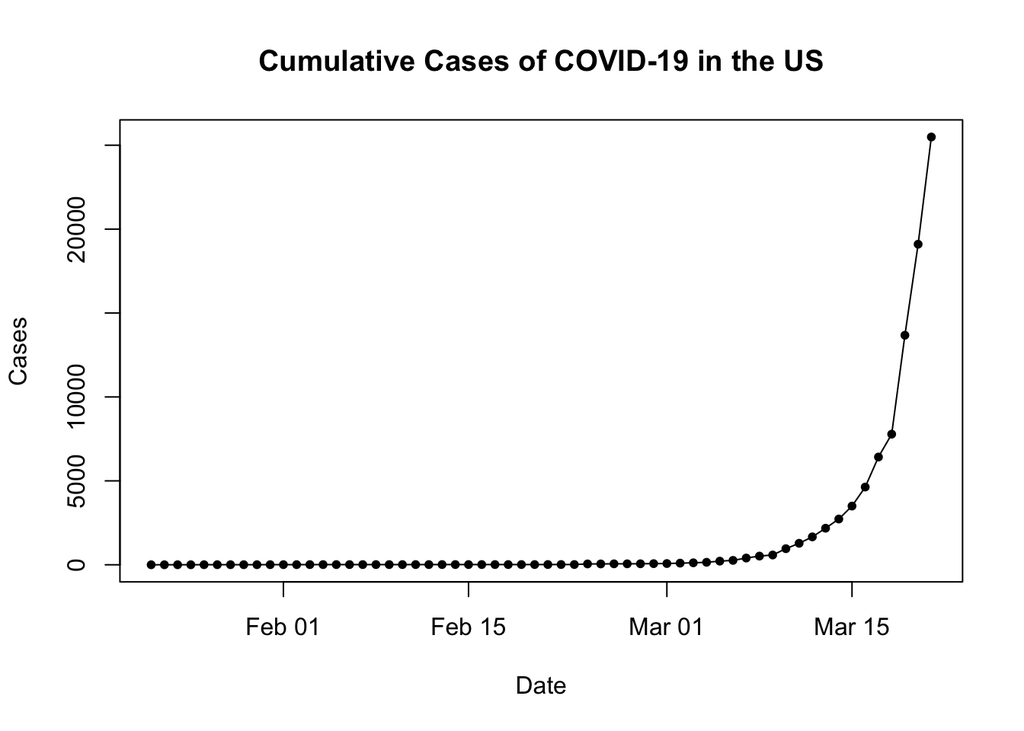

An OLS fit to the logged values shows how closely the pandemic mimics an exponential curve. (All pandemics are modeled as a logistic function since there is a ceiling to the number of infected individuals, but in the growth phase, we can model them as exponential.) If the rate of growth were slowing, points would begin to appear below the fit line.

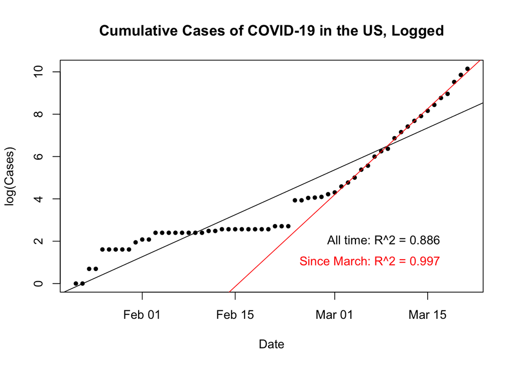

### Growth Rate

This is the famed curve that needs to be flattened so we don’t overwhelm our medical capacity on the first wave of the pandemic. As you can see, we are still climbing.

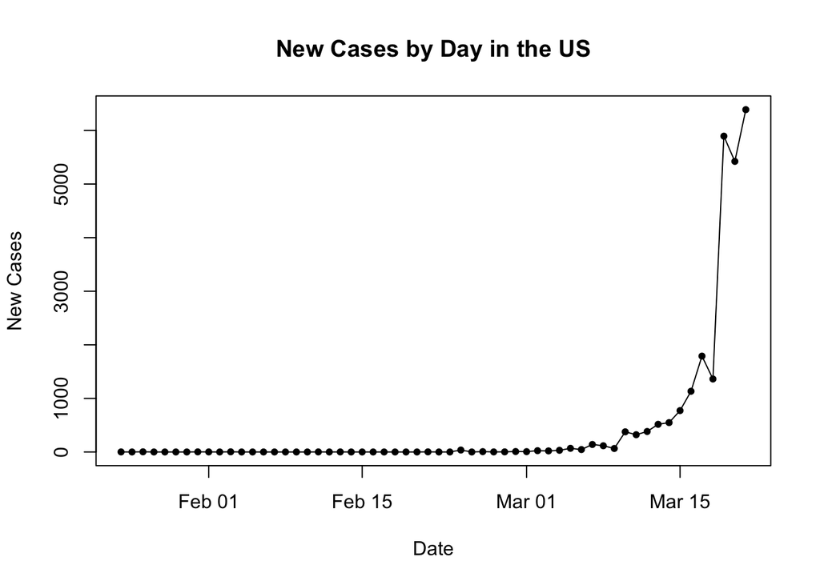

Now, let’s see the y-axis with the new cases as a multiple of the number of new cases the previous day. This is akin to the second derivative of the growth function. We want this to approach 0 as we flatten the curve.

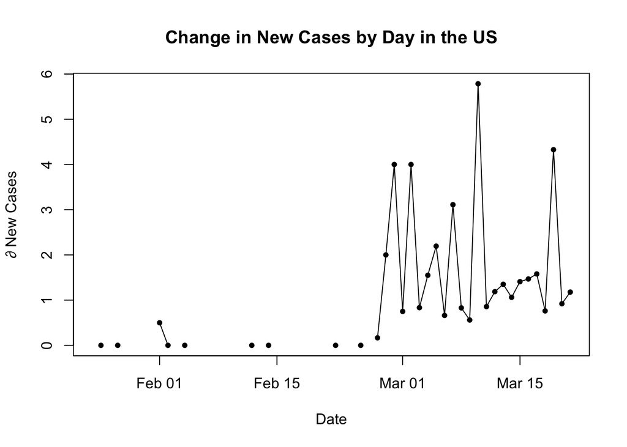

### Table

| Date | Cases | ∂ Cases | New Cases | ∂ New Cases |
| --- | --- | --- | --- | --- |
| 2020-03-01 | 74 | 1.088 | 6 | 0.750 |
| 2020-03-02 | 98 | 1.324 | 24 | 4.000 |
| 2020-03-03 | 118 | 1.204 | 20 | 0.833 |
| 2020-03-04 | 149 | 1.263 | 31 | 1.550 |
| 2020-03-05 | 217 | 1.456 | 68 | 2.194 |
| 2020-03-06 | 262 | 1.207 | 45 | 0.662 |
| 2020-03-07 | 402 | 1.534 | 140 | 3.111 |
| 2020-03-08 | 518 | 1.289 | 116 | 0.829 |
| 2020-03-09 | 583 | 1.125 | 65 | 0.560 |
| 2020-03-10 | 959 | 1.645 | 376 | 5.785 |
| 2020-03-11 | 1281 | 1.336 | 322 | 0.856 |
| 2020-03-12 | 1663 | 1.298 | 382 | 1.186 |
| 2020-03-13 | 2179 | 1.310 | 516 | 1.351 |
| 2020-03-14 | 2727 | 1.251 | 548 | 1.062 |
| 2020-03-15 | 3499 | 1.283 | 772 | 1.409 |
| 2020-03-16 | 4632 | 1.324 | 1133 | 1.468 |
| 2020-03-17 | 6421 | 1.386 | 1789 | 1.579 |
| 2020-03-18 | 7783 | 1.212 | 1362 | 0.761 |
| 2020-03-19 | 13677 | 1.757 | 5894 | 4.327 |
| 2020-03-20 | 19100 | 1.397 | 5423 | 0.920 |
| 2020-03-21 | 25489 | 1.335 | 6389 | 1.178 |